# Project Data Proposal

> General mills and kelloggs appear to make up most of the sugar. This plot makes it apparent of the skewness present in the data, possibly due to size of the cereal companies. Generalmills and Kelloggs are two of the largest cereal companies in the United States.

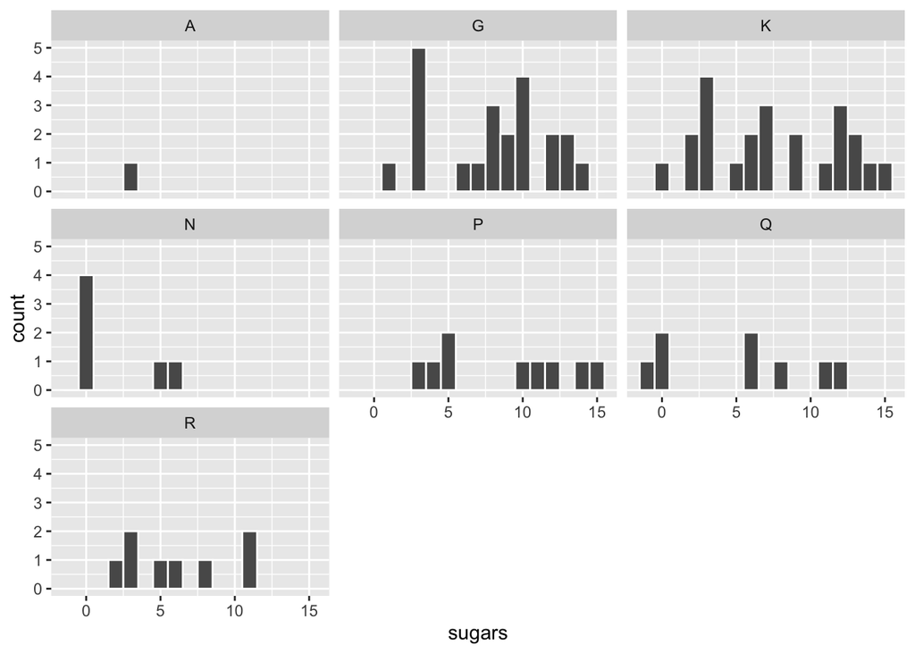

```r
ggplot(data = Cereals_Data, mapping = aes(x = sugars)) +
  geom_histogram(binwidth = 1, color = "white") +
  facet_wrap(~ mfr)
```

Kellogg has the highest sum of ratings for the cereals data. This may not be accurate due to the fact there is an uneven number of cereals that represent every manafacturer. Kelloggs has a total of 23 cereals represented in the data while manafacturers like American Food Products only has one.

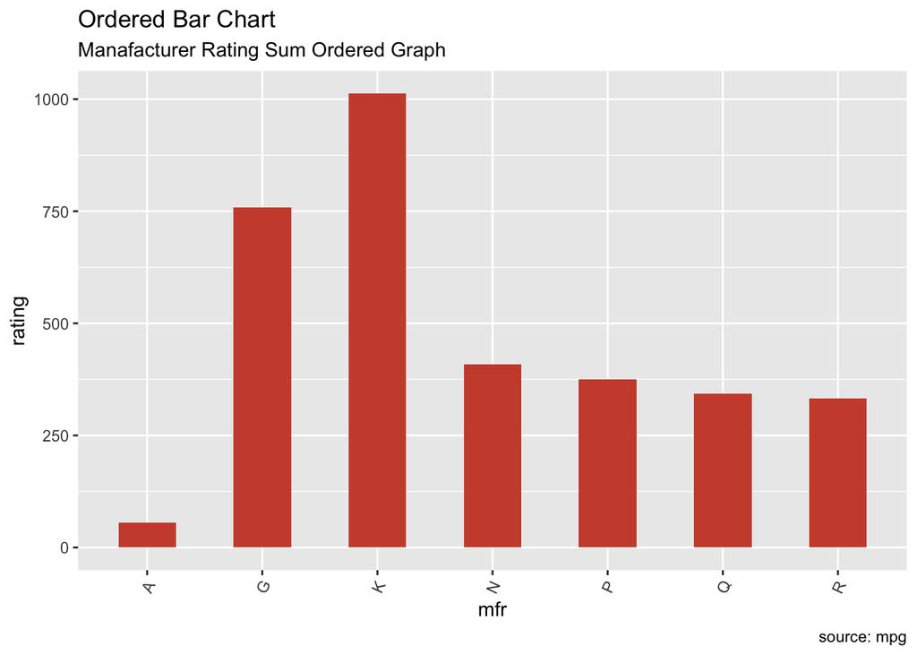

```r
#Ordered barchart of sum rating for cereals by manafacturer

ggplot(Cereals_Data, aes(x=mfr, y=rating)) +
  geom_bar(stat="identity", width=.5, fill="tomato3") +
  labs(title="Ordered Bar Chart",
       subtitle="Manafacturer Rating Sum Ordered Graph",
       caption="source: mpg") +
  theme(axis.text.x = element_text(angle=65, vjust=0.6))
```

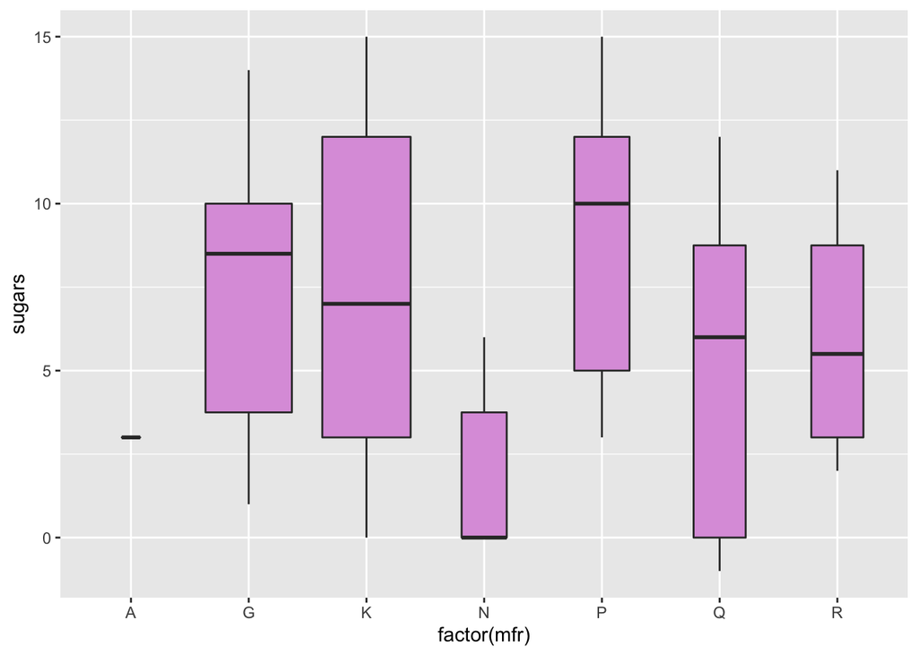

```r
# A better visualization of the sugar content by manafacture. Boxplot and violin plot

#

ggplot(data = Cereals_Data, mapping = aes(x = factor(mfr), y = sugars)) +
  geom_boxplot(varwidth=T, fill="plum")
```